# Capstone Project - Forecasting Seven Day Mean of Log Squared Bitcoin Returns

Author

Fernando Villegas

# Introduction

Cryptocurrency markets are famously volatile and highly unpredictable. It is a great challenge to try to accurately predict the way the price of a cryptocurrency asset such as Bitcoin (BTC) is going to move. However, similar to assets in equity markets, the volatility of the BTC returns can signal risk and it it usually exhibits some sort of persistance or clustering that one could attempt to forecast. Starting from the price series of BTC, one can take the log of the new price divided by yesterday’s price, the so-called log returns, which is typically a stationary series. Taking the squared log returns serves then as a volatility proxy for the BTC return series. Classical statistical models such as ARCH/GARCH are typically used to forecast variances, so we can directly construct forecasts for the squared log returns from by adding teh forecasted variance plus the square of the mean of the series (assuming a constant mean specification).

However, an interesting question can be asked if one considers exogeneous factors that could help predict the series in question. Namely, cryptocurrencies have their own sort of version of “fundamentals”, which we call “on-chain” features, particularly for crypto coins that function on a proof of work basis. For BTC, some of these are mining difficulty: how difficult it is to solve the puzzle that opens the next block in the chain, hash rate: the computational power needed or used to secure the next block, and transaction fees in BTC: how much a miner is paid to process a transaction on the blockchain. There are several other features, but for these project we focus on these three.

The main goal is to explore machine learning models to forecast the seven-day mean of the squared log returns using features only dictated by the market, and compare the performance to the using an expanded feature set with the on-chain features of mining difficulty, hash rate and transaction fees in BTC. We also compare these results against the classical statistical methods to see whether machine learning adapts better to the non-linear relationships the data may have, and we compare as well against a naive baseline to see if any of the models justify their complexity.

We remark that we do not use the on-chain data for the classical ARCH/GARCH due to the `arch` package not supporting exogeneous variables to forecast variance (the package supports exogeneous variables to forecast the mean though), so a separate implementation would be needed to see if the on-chain features directly help at forecasting the conditional variance. We also do not claim that the results from this project establish any causal relationship, we simply mean to understand if these on-chain features help predict the next seven-day average of the squared lof returns.

In what follows we go into detail of our forecasting target, the data we used, and the pipeline and diagnostics we followed to produce forecasts, as well as the conclusions we could draw from these experiments.

# 1. Problem Framing

Let $P_t$ be the daily closing BTC price in USD at time $t$. The log return is defined by $r_t = \log(P_t/P_{t-1})$, which is an approximation of the return $(P_t - P_{t-1})/P_{t-1}$. Our volatility proxy is then $v_t = r_t^2$. Our aim is to predict
$$Y_t = \frac{1}{7}\sum_{h=1}^7 v_{t+h},$$
the seven day mean of the squared log returns. The decision for taking the mean as the forecasting target is from the intuition that $v_t$ is a noisy volatility proxy, and so taking the average of the forecasts smooths out some of the noise and forecasts a single value, rather than seven different ones that could be less stable. Forecasts are made at the end od day $t$, after the closing and volume of BTC are observed. We will also use seven day lagged reports of mining difficulty, hash rate and transaction fees, in order to guarantee that at the forecast origin these values are available.

All forecasts will be compared against the natural naive baseline, which in this case is the previous seven day mean of the squared log returns
$$\widehat{Y}^{\text{naive}}_{t}:= \frac{1}{7}\sum_{j = 0}^6 r_{t-j}^2$$

Our methodology is two-fold. First, we follow the statistical pipeline to fit a classical ARCH/GARCH model to the series, using statistical tests for diagnostics and model validation. We freeze a model and then we make the forecast on teh test period. Second, we do some feature engineering and hyperparameter tuning to fit and validate machine learning tree based models, which again we finally evaluate on the test data. At the end we compare our results and present our conclusions.

It is worth mentioning that we chose to experiment with tree-methods rather than with more complex neural networks solely on the fact that upon making the decision of forecasting the seven day mean return, the number of training, validation and test observations became much smaller, so the sample size was not large enough to justify a very complicated neural network model.

# 2. Data and Exploratory Diagnostics

## 2.1 Provenance

The provided BTC dataset includes the opening and closing price, high and low prices, volume and the log return and square log returns, computed directly from the close. By the formula of the log return, this means we lose the first row for the log return and squared log return, but otherwise the data covers the BTC price series from January 1, 2020, all the way t December 31, 2024. This gives 1827 calendar dates, for which 1826 we have the full information.

```python
from capstone_data import load_dataset, chronological_split
import numpy as np
import pandas as pd
import matplotlib.pyplot as plt

btc = load_dataset("bitcoin")

train, validation, test = chronological_split(btc)

print("Dataset shape:", btc.shape)

print("\nFirst observations:")
display(btc.head())

print("\nLast observations:")
display(btc.tail())

print("\nMissing values:")
print(btc.isna().sum())
```

```
Dataset shape: (1827, 7)

First observations:
```

| time | Close | High | Low | Open | Volume | log_return | squared_log_return |
| --- | --- | --- | --- | --- | --- | --- | --- |
| 2020-01-01 | 7200.174316 | 7254.330566 | 7174.944336 | 7194.892090 | 18565664997 | NaN | NaN |
| 2020-01-02 | 6985.470215 | 7212.155273 | 6935.270020 | 7202.551270 | 20802083465 | -0.030273 | 9.164502e-04 |
| 2020-01-03 | 7344.884277 | 7413.715332 | 6914.996094 | 6984.428711 | 28111481032 | 0.050172 | 2.517204e-03 |
| 2020-01-04 | 7410.656738 | 7427.385742 | 7309.514160 | 7345.375488 | 18444271275 | 0.008915 | 7.947740e-05 |
| 2020-01-05 | 7411.317383 | 7544.497070 | 7400.535645 | 7410.451660 | 19725074095 | 0.000089 | 7.946641e-09 |

```
Last observations:
```

| time | Close | High | Low | Open | Volume | log_return | squared_log_return |
| --- | --- | --- | --- | --- | --- | --- | --- |
| 2024-12-27 | 94164.859375 | 97294.843750 | 93310.742188 | 95704.976562 | 52419934565 | -0.017169 | 0.000295 |
| 2024-12-28 | 95163.929688 | 95525.898438 | 94014.289062 | 94160.187500 | 24107436185 | 0.010554 | 0.000111 |
| 2024-12-29 | 93530.226562 | 95174.875000 | 92881.789062 | 95174.054688 | 29635885267 | -0.017316 | 0.000300 |
| 2024-12-30 | 92643.210938 | 94903.320312 | 91317.132812 | 93527.195312 | 56188003691 | -0.009529 | 0.000091 |
| 2024-12-31 | 93429.203125 | 96090.601562 | 91914.031250 | 92643.250000 | 43625106843 | 0.008448 | 0.000071 |

```
Missing values:
Close                 0
High                  0
Low                   0
Open                  0
Volume                0
log_return            1
squared_log_return    1
dtype: int64
```

Since for the ML modeling we seek to use on-chain features, we collect the data for mining difficulty, hash rate and transaction fees in BTC using the Blockchain.com API, which provide the full historical data for these datasets. We requested daily observations from December 1, 2019 to February 12, 2025, covering a larger period than the BTC dataset. We intend to use this data lagged by seven days, so after downloading the raw data from the API, we lagged the features by seven days and aligned the two datasets so that at time $t$, the $t-7$ on-chain features data is available. The lag is to ensure the requested data is available at the forecast origin and avoid the problem of having to forecast these variables as well.

```python
import requests
import pandas as pd

BASE_URL = "https://api.blockchain.info/charts"

charts = {
    "hash_rate": "hash-rate",
    "difficulty": "difficulty",
    "fees_btc": "transaction-fees"
}

def download_blockchain_chart(chart_name):

    url = f"{BASE_URL}/{chart_name}"

    params = {
        "start": "2019-12-01",
        "timespan": "1900days",
        "format": "json",
        "sampled": "false"
    }

    response = requests.get(
        url,
        params=params,
        timeout=40
    )

    response.raise_for_status()

    data = response.json()

    if data.get("status") != "ok":
        raise ValueError(f"Unexpected API response: {data}")

    if data.get("period") != "day":
        raise ValueError(
            f"Expected daily observations, got {data.get('period')}"
        )

    values = pd.DataFrame(data["values"])

    if values.empty:
        raise ValueError(f"No observations returned for {chart_name}")

    dates = (
        pd.to_datetime(values["x"], unit="s", utc=True)
        .dt.normalize()
        .dt.tz_localize(None)
    )

    series = pd.Series(
        pd.to_numeric(values["y"], errors="coerce").to_numpy(),
        index=pd.DatetimeIndex(dates),
        name=chart_name
    ).sort_index()

    if not series.index.is_unique:
        raise ValueError(f"Duplicate daily dates for {chart_name}")

    return series

onchain = pd.concat(
    {
        name: download_blockchain_chart(chart)
        for name, chart in charts.items()
    },
    axis=1
)

print(onchain.shape)

display(onchain.head())
display(onchain.tail())

print("\nMissing values:")
print(onchain.isna().sum())

onchain.to_csv(
    "btc_onchain_raw.csv",
    index_label="date"
)

onchain_cols = ["hash_rate", "difficulty", "fees_btc"]

btc_full = btc.join(
    onchain,
    how="left",
    validate="one_to_one"
)

# Lag on the full historical series, including December 2019.
onchain_lagged = onchain[onchain_cols].shift(7)

onchain_lagged = onchain_lagged.rename(
    columns={col: f"{col}_lag7" for col in onchain_cols}
)

# Align only after creating the lags.
btc_full = btc_full.join(
    onchain_lagged,
    how="left",
    validate="one_to_one"
)

lagged_cols = onchain_lagged.columns.tolist()

print(btc_full[lagged_cols].isna().sum())

print("Combined dataset shape:", btc_full.shape)
display(btc_full.head())

btc_full.to_csv(
    "btc_market_onchain_aligned.csv",
    index_label="date"
)
```

```
(1901, 3)
```

| x | hash_rate | difficulty | fees_btc |
| --- | --- | --- | --- |
| 2019-12-01 | 8.964153e+07 | 1.297324e+13 | 21.908764 |
| 2019-12-02 | 9.351094e+07 | 1.297324e+13 | 26.091090 |
| 2019-12-03 | 1.018947e+08 | 1.297324e+13 | 25.477341 |
| 2019-12-04 | 1.076988e+08 | 1.297324e+13 | 29.545539 |
| 2019-12-05 | 9.338636e+07 | 1.295595e+13 | 23.241657 |

| x | hash_rate | difficulty | fees_btc |
| --- | --- | --- | --- |
| 2025-02-08 | 8.598320e+08 | 1.081054e+14 | 4.520147 |
| 2025-02-09 | 7.952938e+08 | 1.118782e+14 | 3.493630 |
| 2025-02-10 | 7.888647e+08 | 1.141673e+14 | 4.581370 |
| 2025-02-11 | 7.037354e+08 | 1.141673e+14 | 5.258301 |
| 2025-02-12 | 7.548130e+08 | 1.141673e+14 | 4.636798 |

```
Missing values:
hash_rate     0
difficulty    0
fees_btc      0
dtype: int64
hash_rate_lag7     0
difficulty_lag7    0
fees_btc_lag7      0
dtype: int64
Combined dataset shape: (1827, 13)
```

| time | Close | High | Low | Open | Volume | log_return | squared_log_return | hash_rate | difficulty | fees_btc | hash_rate_lag7 | difficulty_lag7 | fees_btc_lag7 |
| --- | --- | --- | --- | --- | --- | --- | --- | --- | --- | --- | --- | --- | --- |
| 2020-01-01 | 7200.174316 | 7254.330566 | 7174.944336 | 7194.892090 | 18565664997 | NaN | NaN | 1.127185e+08 | 1.303166e+13 | 9.971000 | 8.239079e+07 | 1.294859e+13 | 13.131968 |
| 2020-01-02 | 6985.470215 | 7212.155273 | 6935.270020 | 7202.551270 | 20802083465 | -0.030273 | 9.164502e-04 | 9.671772e+07 | 1.379878e+13 | 13.780845 | 1.074942e+08 | 1.294859e+13 | 18.912097 |
| 2020-01-03 | 7344.884277 | 7413.715332 | 6914.996094 | 6984.428711 | 28111481032 | 0.050172 | 2.517204e-03 | 1.159241e+08 | 1.379878e+13 | 16.389795 | 9.333332e+07 | 1.294859e+13 | 17.116338 |
| 2020-01-04 | 7410.656738 | 7427.385742 | 7309.514160 | 7345.375488 | 18444271275 | 0.008915 | 7.947740e-05 | 1.152381e+08 | 1.379878e+13 | 12.312165 | 9.590803e+07 | 1.294859e+13 | 13.803910 |
| 2020-01-05 | 7411.317383 | 7544.497070 | 7400.535645 | 7410.451660 | 19725074095 | 0.000089 | 7.946641e-09 | 1.118084e+08 | 1.379878e+13 | 11.887112 | 9.977010e+07 | 1.294859e+13 | 12.609247 |

## 2.2 Splitting the data and stationarity

We separate the data using a chronological 60/20/20% split, which is handled by the `chronological_split` helper from the `capstone_data.py` file. This corresponds to exactly having the training period be 2020-2022, validation period is 2023 and the test period is 2024.

We also note that typically log returns can be expressed in percentages, so in order to present the data in this way, we multiply the return series by $100$ and consequently the squared log return series by $100^2 = 10000$. This is done consistently through the code as well.

```python
train, validation, test = chronological_split(btc_full)

print("Train:", train.shape)
print("Validation:", validation.shape)
print("Test:", test.shape)

v_train = train["squared_log_return"]

# Target at time t: mean of squared returns at t+1, ..., t+7
y_train = (
    v_train.rolling(window=7, min_periods=7)
    .mean()
    .shift(-7)
    .dropna()
)

print(y_train.describe())
print(y_train.index.min(), y_train.index.max())
```

```
Train: (1096, 13)
Validation: (365, 13)
Test: (366, 13)
count    1089.000000
mean        0.001511
std         0.002900
min         0.000013
25%         0.000453
50%         0.000915
75%         0.001696
max         0.034666
Name: squared_log_return, dtype: float64
2020-01-01 00:00:00 2022-12-24 00:00:00
```

The training data has 1096 dates, and since we want to train the seven day averages, the training has 1089 complete seven-day labels. The statistics here are before scaling by $100^2$, given this is the first display of the raw, but we can see that the distribution of the training target is very right skewed. This is evident after seeing the first plots of the target.

|  | 7-day average squared return |
| --- | --- |
| count | 1089.000000 |
| mean | 15.113536 |
| std | 29.002726 |
| min | 0.132538 |
| 1% | 0.521109 |
| 5% | 1.239505 |
| 25% | 4.528212 |
| 50% | 9.149614 |
| 75% | 16.956581 |
| 95% | 38.263099 |
| 99% | 71.823142 |
| max | 346.656175 |
| skewness | 9.191271 |
| excess kurtosis | 98.830865 |

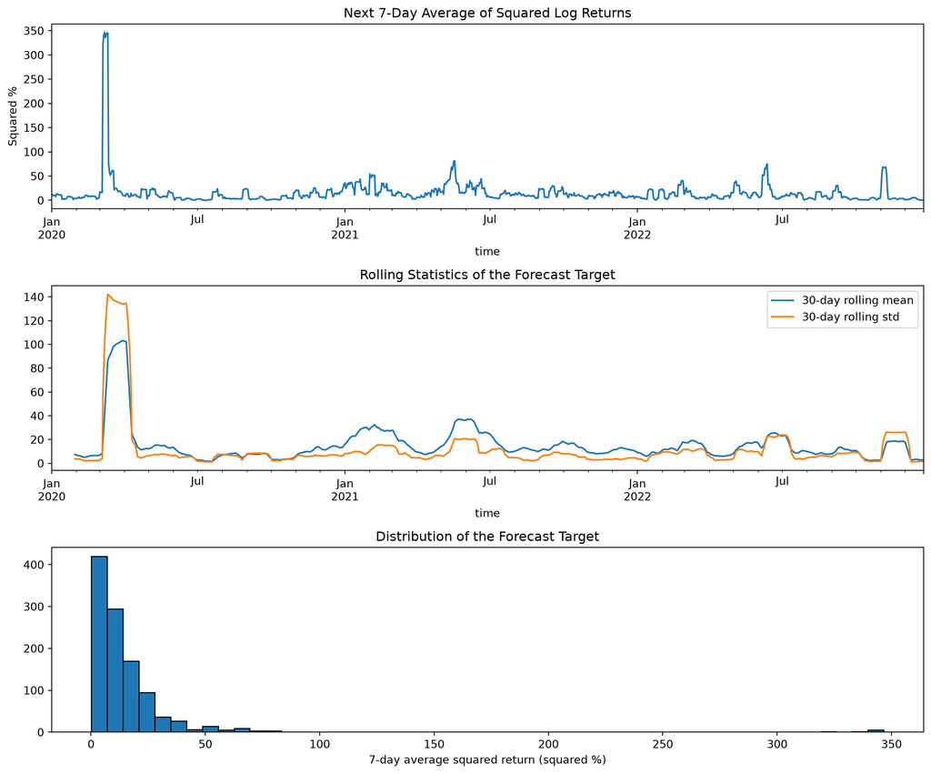

```python
from scipy.stats import skew, kurtosis

y_plot = 10000 * y_train

# Descriptive statistics
summary = y_plot.describe(
    percentiles=[0.01, 0.05, 0.25, 0.5, 0.75, 0.95, 0.99]
)

summary.loc["skewness"] = skew(y_plot)
summary.loc["excess kurtosis"] = kurtosis(y_plot)

display(summary.to_frame("7-day average squared return"))

fig, axes = plt.subplots(3, 1, figsize=(12, 10))

# Target series
y_plot.plot(ax=axes[0])
axes[0].set_title("Next 7-Day Average of Squared Log Returns")
axes[0].set_ylabel("Squared %")

# Rolling mean and standard deviation
y_plot.rolling(30).mean().plot(
    ax=axes[1], label="30-day rolling mean"
)

y_plot.rolling(30).std().plot(
    ax=axes[1], label="30-day rolling std"
)

axes[1].set_title("Rolling Statistics of the Forecast Target")
axes[1].legend()

# Distribution
axes[2].hist(y_plot, bins=50, edgecolor="black")
axes[2].set_title("Distribution of the Forecast Target")
axes[2].set_xlabel("7-day average squared return (squared %)")

plt.tight_layout()
plt.show()
```

The huge spike in early 2020 is most likely due in some manner to COVID, and this episode will affect the exploratory diagnostics we perform in what follows. We should note from this that, at least looking at the training period, the forecasting target is not normally distributed, though this does not necessarily rule out that the use of GARCH models.

We plot the daily log return series and the daily squared log return series as well (on the training period).

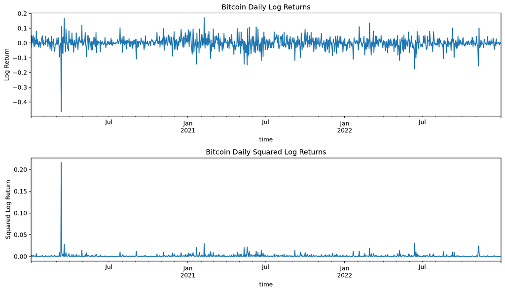

```python
from statsmodels.graphics.tsaplots import plot_acf
from statsmodels.stats.diagnostic import acorr_ljungbox

train, validation, test = chronological_split(btc_full)

r_train = train["log_return"].dropna()
v_train = train["squared_log_return"].dropna()

fig, axes = plt.subplots(2, 1, figsize=(12, 7))

r_train.plot(ax=axes[0])
axes[0].set_title("Bitcoin Daily Log Returns")
axes[0].set_ylabel("Log Return")

v_train.plot(ax=axes[1])
axes[1].set_title("Bitcoin Daily Squared Log Returns")
axes[1].set_ylabel("Squared Log Return")

plt.tight_layout()
plt.show()
```

We run the ADF-test for evidence of a unit root on the target series

```python
from statsmodels.tsa.stattools import adfuller

adf = adfuller(y_train, autolag="AIC")

adf_results = pd.DataFrame({
    "Statistic": [adf[0]],
    "p-value": [adf[1]],
    "Lags used": [adf[2]],
    "Observations": [adf[3]]
}, index=["ADF"])

display(adf_results)
```

|  | Statistic | p-value | Lags used | Observations |
| --- | --- | --- | --- | --- |
| ADF | -5.247437 | 0.000007 | 21 | 1067 |

The test rejects the null hypothesis, so we have statistical evidence for believing the series does not have a unit root and so the series looks stationary. The same applies to the return series:

```python
adf = adfuller(r_train, autolag="AIC")

adf_results = pd.DataFrame({
    "Statistic": [adf[0]],
    "p-value": [adf[1]],
    "Lags used": [adf[2]],
    "Observations": [adf[3]]
}, index=["ADF"])

display(adf_results)
```

|  | Statistic | p-value | Lags used | Observations |
| --- | --- | --- | --- | --- |
| ADF | -10.669771 | 4.196297e-19 | 8 | 1086 |

and to the squared log return series:

```python
adf = adfuller(v_train, autolag="AIC")

adf_results = pd.DataFrame({
    "Statistic": [adf[0]],
    "p-value": [adf[1]],
    "Lags used": [adf[2]],
    "Observations": [adf[3]]
}, index=["ADF"])

display(adf_results)
```

|  | Statistic | p-value | Lags used | Observations |
| --- | --- | --- | --- | --- |
| ADF | -10.564003 | 7.599378e-19 | 6 | 1088 |

Hence, for all three series: log returns, squared log returns and seven day mean of squared log returns, we have statistical evidence to believe they do not have a unit root and thus are stationary.

We also plot the three on-chain features and compute their correlations.

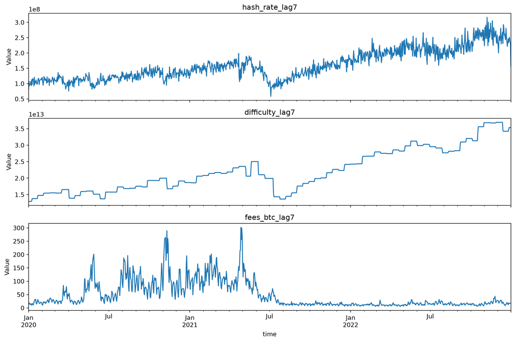

```
Training-period correlation matrix:
```

|  | hash_rate_lag7 | difficulty_lag7 | fees_btc_lag7 |
| --- | --- | --- | --- |
| hash_rate_lag7 | 1.000 | 0.928 | -0.344 |
| difficulty_lag7 | 0.928 | 1.000 | -0.297 |
| fees_btc_lag7 | -0.344 | -0.297 | 1.000 |

```python
onchain_features = [
    "hash_rate_lag7",
    "difficulty_lag7",
    "fees_btc_lag7"
]

fig, axes = plt.subplots(3, 1, figsize=(12, 8), sharex=True)

for ax, col in zip(axes, onchain_features):
    train[col].plot(ax=ax)
    ax.set_title(col)
    ax.set_ylabel("Value")

plt.tight_layout()
plt.show()

print("Training-period correlation matrix:")
display(train[onchain_features].corr().round(3))
```

We see that the hash rate and the difficulty are heavily correlated, and this is also evident from the plots. We decided to retain these features, having in mind that for the machine learning models this could be a limitation in understanding which of the two features is actually helping.

# 3. Statistical Modeling

## 3.1 Exploratory diagnostics

We begin this section by continuing exploring the training period’s data. We plot the ACF and PACF of the target seven-day mean series first, though we note that due to the nature of the target being a mean, i.e. a sum of the squared log returns, the seven day mean on day $t$ will have positive correlation with the seven day of days $t+h$ for $1\leq h \leq 6$, since both include overlapping terms in the summation.

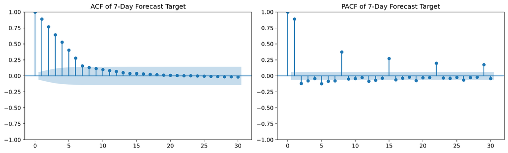

```python
from statsmodels.graphics.tsaplots import plot_acf, plot_pacf

fig, axes = plt.subplots(1, 2, figsize=(13, 4))

plot_acf(
    y_train,
    lags=30,
    ax=axes[0],
    title="ACF of 7-Day Forecast Target"
)

plot_pacf(
    y_train,
    lags=30,
    method="ywm",
    ax=axes[1],
    title="PACF of 7-Day Forecast Target"
)

plt.tight_layout()
plt.show()
```

Because of the above, to have a clearer image of actual autocorrelations, we also plot the ACF for the squared log returns.

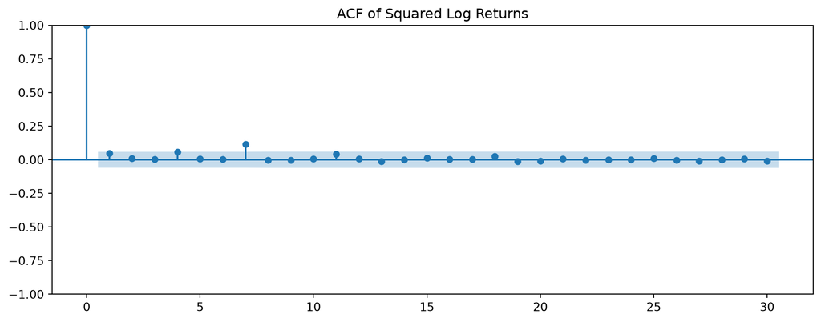

```python
fig, ax = plt.subplots(figsize=(10, 4))

plot_acf(v_train, lags=30, ax=ax)

ax.set_title("ACF of Squared Log Returns")

plt.tight_layout()
plt.show()
```

We remark that there is a clear single spike at lag 7 for this autocorrelation.

Similarly, we run the Ljung-Box test on the target series, but the result may not be informative in the sense that knowing the autocorrelation is positive by design, we expect the test to reject at several lags, rejecting the null hypothesis of being white noise.

```python
from statsmodels.stats.diagnostic import acorr_ljungbox

lb_target = acorr_ljungbox(
    y_train,
    lags=[7, 14, 21, 28],
    return_df=True
)

display(lb_target)
```

|  | lb_stat | lb_pvalue |
| --- | --- | --- |
| 7 | 2559.644379 | 0.0 |
| 14 | 2621.909306 | 0.0 |
| 21 | 2626.119697 | 0.0 |
| 28 | 2626.437013 | 0.0 |

However, running the Ljung-Box test for the non-overlapping squared log returns gives the following information:

```python
lb_daily = acorr_ljungbox(
    v_train.dropna(),
    lags=[7, 14, 21, 28],
    return_df=True
)

display(lb_daily)
```

|  | lb_stat | lb_pvalue |
| --- | --- | --- |
| 7 | 20.831976 | 0.004027 |
| 14 | 23.038231 | 0.059650 |
| 21 | 24.426578 | 0.272852 |
| 28 | 24.712676 | 0.643425 |

The test only rejects at lag 7 in this case, suggesting there is some pattern for the squared log-returns around lag 7, but that it possibly dies down over longer horizons.

The above suggests investigating ARCH/GARCH effects. We now perform Engle’s ARCH-LM test over several lags to test for ARCH/GARCH effects on the squared log returns. We proceed with a constant mean specification, so we compute the mean of the log return series, and run the tests on the residuals for lags 1 through 20.

```python
from statsmodels.stats.diagnostic import het_arch
from scipy.stats import jarque_bera

# Percentage returns
r_train_pct = 100 * train["log_return"].dropna()

# Preliminary constant-mean specification
mu_hat = r_train_pct.mean()

resid = r_train_pct - mu_hat

# ARCH-LM tests for several lag choices
arch_results = []

for q in range(1,21):

    lm_stat, lm_p, _, _ = het_arch(
        resid,
        nlags=q
    )

    arch_results.append({
        "Lags": q,
        "LM statistic": lm_stat,
        "p-value": lm_p
    })

display(pd.DataFrame(arch_results))

# Normality diagnostic
jb_stat, jb_p = jarque_bera(resid)

print("Jarque-Bera statistic:", jb_stat)
print("Jarque-Bera p-value:", jb_p)
```

|  | Lags | LM statistic | p-value |
| --- | --- | --- | --- |
| 0 | 1 | 2.594165 | 0.107258 |
| 1 | 2 | 2.663560 | 0.264007 |
| 2 | 3 | 2.675522 | 0.444403 |
| 3 | 4 | 6.321179 | 0.176412 |
| 4 | 5 | 6.319583 | 0.276352 |
| 5 | 6 | 6.312258 | 0.389135 |
| 6 | 7 | 20.074982 | 0.005410 |
| 7 | 8 | 20.412226 | 0.008884 |
| 8 | 9 | 20.417773 | 0.015502 |
| 9 | 10 | 20.473561 | 0.025079 |
| 10 | 11 | 21.230956 | 0.031056 |
| 11 | 12 | 21.224582 | 0.047187 |
| 12 | 13 | 21.374215 | 0.065849 |
| 13 | 14 | 21.482782 | 0.089885 |
| 14 | 15 | 21.669255 | 0.116774 |
| 15 | 16 | 21.652501 | 0.154770 |
| 16 | 17 | 21.659625 | 0.198166 |
| 17 | 18 | 22.009902 | 0.231546 |
| 18 | 19 | 22.298831 | 0.269637 |
| 19 | 20 | 22.352516 | 0.321693 |

```
Jarque-Bera statistic: 19549.71828653177
Jarque-Bera p-value: 0.0
```

The test rejects at lags 7, 8, 9, 10, 11 and 12, and we recall that the null hypothesis for each test at lag $q$ is that the coefficients in the ARCH equation for lags up to $q$ are zero. Hence, rejecting, together with the autocorrelation spike at lag 7 and the fact that at lag 7 Ljung-Box also rejects for the squared log-returns suggest a good candidate to test is ARCH(7).

We note that we also ran the Jarque-Bera test for unconditional normality of the residuals and it rejected, so the residuals fail to be normally distributed, but this does not mean we cannot have conditional Gaussian innovations. We assume conditional Gaussian innovation for the rest of this project, though in hindsight we recognize we shoudl have run diagnostics to determine whether Gaussian GARCH or perhaps t-student GARCH specifications could have been more appropriate. We discuss this again in the limitations sections.

To further investigate the lag 7 spike, we compute the lag 7 ACF of daily squared log returns separately by training year.

```python
v_train = train["squared_log_return"].dropna()

rows = []

for year, series in v_train.groupby(v_train.index.year):

    rows.append({
        "Year": year,
        "Observations": len(series),
        "ACF lag 7": series.autocorr(lag=7)
    })

display(pd.DataFrame(rows))
```

|  | Year | Observations | ACF lag 7 |
| --- | --- | --- | --- |
| 0 | 2020 | 365 | 0.119326 |
| 1 | 2021 | 365 | 0.117754 |
| 2 | 2022 | 365 | 0.003785 |

While the lag 7 ACF was similar for the first two years, the same is not true for 2022, so this potential weekly structure is not stable across periods. So from this we included ARCH(7) as a candidate, but not a weekly-only ARCH or interpreting the structure as some sort of cycle.

## 3.2 Candidates: classical volatility models

We work now with percentage returns $R_t = 100 r_t$, not only for convention, but also for numerical stability, as the quantities are small and may become numerically zero under cetain operations despite still carrying data. This is not super important, but we thought better to clarify it. We assume a constant conditional mean $R_t = \mu + \epsilon_t$. We consider ARCH(p) models

$$\sigma_t^2 = \omega + \sum_{i = 1}^p \alpha_i \epsilon_{t - i}^2$$
and GARCH(p,q) models
$$\sigma_t^2 = \omega + \sum_{i = 1}^p \alpha_i \epsilon_{t - i}^2 + \sum_{j = 1}^q \beta_j \sigma_{t-j}^2$$
working under the assumption that $\epsilon_t = \sigma_t z_t$, $z_t \underset{\text{i.i.d}}{\sim} N(0,1)$.

The initial diagnostics strongly suggested an ARCH(7) configuration. We add to the candidate list surrounding models such as ARCH(1) and ARCH(5), which although the diagnostic tests did not offer strong evidence, they are simpler models that give somewhat of a benchmark for understanding if the ARCH(7) complexity is necessary or even helpful for better forecasts. Following similar reasoning, we considered GARCH(1,1) and GARCH(2,1), which are the simpler GARCH models. These are worthy to investigate also on the merit that GARCH models add lagged conditional variances, allowing for the variance to remember, which on principle could be appropriate for markets such as BTC which typically experience effects from market regimes. Hence, the five models to be compared are ARCH(1), ARCH(5), ARCH(7) and GARCH(1,1) and GARCH(2,1).

Our first diagnostic is computing AIC and BIC, as well as the persistance of each model, i.e. the measure at which past shocks persist on the future forecast.

```python
import numpy as np
import pandas as pd
from arch import arch_model

# Training data: 2020-2022
train, validation, test = chronological_split(btc_full)

# Use percentage log returns for numerical stability
r_train = 100 * train["log_return"].dropna()

# Candidate specifications
candidates = {
    "ARCH(1)":    {"vol": "ARCH",  "p": 1},
    "ARCH(5)":    {"vol": "ARCH",  "p": 5},
    "ARCH(7)":    {"vol": "ARCH",  "p": 7},
    "GARCH(1,1)": {"vol": "GARCH", "p": 1, "q": 1},
    "GARCH(2,1)": {"vol": "GARCH", "p": 2, "q": 1}
}

fitted_models = {}
results = []

for name, spec in candidates.items():

    model = arch_model(
        r_train,
        mean="Constant",
        dist="normal",
        hold_back=7,
        rescale=False,
        **spec
    )

    fit = model.fit(disp="off")
    fitted_models[name] = fit

    # Persistence: sum of ARCH and GARCH coefficients
    persistence = sum(
        value for param, value in fit.params.items()
        if param.startswith(("alpha[", "beta["))
    )

    results.append({
        "Model": name,
        "Log-Likelihood": fit.loglikelihood,
        "AIC": fit.aic,
        "BIC": fit.bic,
        "Persistence": persistence,
        "Convergence": fit.convergence_flag
    })

comparison = (
    pd.DataFrame(results)
    .set_index("Model")
    .sort_values("BIC")
)

display(comparison.round(4))
```

| Model | Log-Likelihood | AIC | BIC | Persistence | Convergence |
| --- | --- | --- | --- | --- | --- |
| ARCH(7) | -2951.7512 | 5921.5024 | 5966.4313 | 0.5139 | 0 |
| ARCH(5) | -2963.6911 | 5941.3821 | 5976.3268 | 0.4218 | 0 |
| GARCH(1,1) | -2991.9274 | 5991.8547 | 6011.8231 | 0.9361 | 0 |
| GARCH(2,1) | -2989.6473 | 5989.2945 | 6014.2550 | 0.9261 | 0 |
| ARCH(1) | -3016.3426 | 6038.6853 | 6053.6616 | 0.0345 | 0 |

In terms of AIC and BIC ARCH(7) wins over all models. GARCH(1,1) sits in the middle of the pack and surprisingly the simplest theortical model is the one that gets punished the most, since its likelihood is too negative. This is again, in sample diagnostics, so we should investigate the validation scores before we freeze a model and move on to forecasting. From this diagnostic we discard the bottom two models and keep the top three to move into validation.

## 3.3 Forecasting and validation

First, we mention that we reconstruct the forecasts for the squared log returns using the definition of variance:

$$\mathbb{E}[R^2_{t+h}|\mathcal{F}_t] = \mu^2 + \mathbb{E}[\sigma^2_{t+h}|\mathcal{F}_t]$$
and thus, from the variance forecast produced from the variance ARCH/GARCH models, we compute the forecasts via
$$\begin{aligned}
\widehat{Y}_t
&= \frac{1}{7}\sum_{h = 1}^7 \widehat{r}^2_{t+h}\\
&= \frac{1}{7}\sum_{h = 1}^7 \frac{100^2}{100^2}\widehat{r}^2_{t+h}\\
&= \frac{1}{7(100)^2}\sum_{h = 1}^7 \widehat{R}^2_{t+h}\\
&= \frac{1}{7(10)^4}\sum_{h = 1}^7 (\mu^2 + \widehat{\sigma}^2_{t+h})
\end{aligned}$$
At each weekly validation origin, models were refitted using return observed through the origin, then the seven-step horizon forecast of the conditional variance was used and averaged to make the forecast of the seven-day mean.

```python
from arch import arch_model
from sklearn.metrics import mean_absolute_error, mean_squared_error

import numpy as np
import pandas as pd

H = 7

candidates = {
    "ARCH(5)": {"vol": "ARCH", "p": 5},
    "ARCH(7)": {"vol": "ARCH", "p": 7},
    "GARCH(1,1)": {"vol": "GARCH", "p": 1, "q": 1},
}

# Use the same estimation hold-back for every model.
hold_back = 8

# First forecast origin: December 31, 2022.
# 52 complete nonoverlapping target windows in 2023.
origins = pd.date_range(
    start=validation.index.min() - pd.Timedelta(days=1),
    periods=len(validation) // H,
    freq="7D"
)

records = []

for origin in origins:

    # All observed returns through this forecast origin.
    history = (
        100 * btc_full.loc[:origin, "log_return"].dropna()
    )

    # The actual next 7 days, used only for evaluation.
    future = btc_full.loc[
        origin + pd.Timedelta(days=1):
        origin + pd.Timedelta(days=H),
        "squared_log_return"
    ]

    # Previous 7 days for the naive benchmark.
    past = btc_full.loc[
        origin - pd.Timedelta(days=H-1):
        origin,
        "squared_log_return"
    ]

    assert len(future) == H and future.notna().all()
    assert len(past) == H and past.notna().all()
    assert future.index.min() >= validation.index.min()
    assert future.index.max() <= validation.index.max()

    row = {
        "origin": origin,
        "target_end": future.index[-1],
        "actual": future.mean(),
        "Naive": past.mean()
    }

    for name, spec in candidates.items():

        model = arch_model(
            history,
            mean="Constant",
            dist="normal",
            hold_back=hold_back,
            rescale=False,
            **spec
        )

        fit = model.fit(disp="off")

        if fit.convergence_flag != 0:
            raise RuntimeError(
                f"{name} failed to converge at {origin}"
            )

        fc = fit.forecast(
            horizon=H,
            method="analytic",
            reindex=False
        )

        # Predictive means and variances in percentage units.
        mean_fc = fc.mean.iloc[-1].to_numpy()
        var_fc = fc.variance.iloc[-1].to_numpy()

        # E[r^2] = Var(r) + E[r]^2.
        # Divide by 10,000 to return to log-return scale.
        squared_fc = (var_fc + mean_fc**2) / 10000

        if not np.isfinite(squared_fc).all():
            raise ValueError(
                f"Nonfinite forecast: {name}, {origin}"
            )

        row[name] = squared_fc.mean()

    records.append(row)

validation_forecasts = (
    pd.DataFrame(records)
    .set_index("origin")
)

display(validation_forecasts.head())
```

| origin | target_end | actual | Naive | ARCH(5) | ARCH(7) | GARCH(1,1) |
| --- | --- | --- | --- | --- | --- | --- |
| 2022-12-31 | 2023-01-07 | 0.000029 | 0.000044 | 0.001162 | 0.000990 | 0.000967 |
| 2023-01-07 | 2023-01-14 | 0.001322 | 0.000029 | 0.001139 | 0.000956 | 0.000876 |
| 2023-01-14 | 2023-01-21 | 0.000912 | 0.001322 | 0.001732 | 0.001671 | 0.001462 |
| 2023-01-21 | 2023-01-28 | 0.000104 | 0.000912 | 0.001546 | 0.001448 | 0.001447 |
| 2023-01-28 | 2023-02-04 | 0.000507 | 0.000104 | 0.001156 | 0.000985 | 0.001055 |

We also produced the validation forecasts for the naive baseline, and now we compare their performance against the actual values on the validation period by reporting RMSE and MAE.

```python
rows = []

model_names = ["Naive"] + list(candidates)

for name in model_names:

    actual = validation_forecasts["actual"]
    predicted = validation_forecasts[name]

    mae = mean_absolute_error(actual, predicted)
    rmse = np.sqrt(mean_squared_error(actual, predicted))

    rows.append({
        "Model": name,
        "MAE": mae,
        "RMSE": rmse,
        "MAE (x1e4)": mae * 10000,
        "RMSE (x1e4)": rmse * 10000
    })

validation_scores = (
    pd.DataFrame(rows)
    .set_index("Model")
    .sort_values("RMSE")
)

display(validation_scores.round(6))
```

| Model | MAE | RMSE | MAE (x1e4) | RMSE (x1e4) |
| --- | --- | --- | --- | --- |
| GARCH(1,1) | 0.000645 | 0.000746 | 6.446823 | 7.458555 |
| Naive | 0.000530 | 0.000755 | 5.296405 | 7.550006 |
| ARCH(7) | 0.000695 | 0.000801 | 6.945267 | 8.008262 |
| ARCH(5) | 0.000766 | 0.000862 | 7.655748 | 8.624212 |

It turned out that GARCH(1,1) had the smallest RMSE, while the baseline obtained the lowest MAE, suggesting that perhaps GARCH(1,1) generalizes better. After all, we did observe that the lag 7 structure seemed to dissapear across subperiods, though this statement is merely hypothetical.

Taking RMSE as our final filter, at this stage we freeze our choice as GARCH(1,1) to move into forecasting. However, we make an additional exploratory observation.

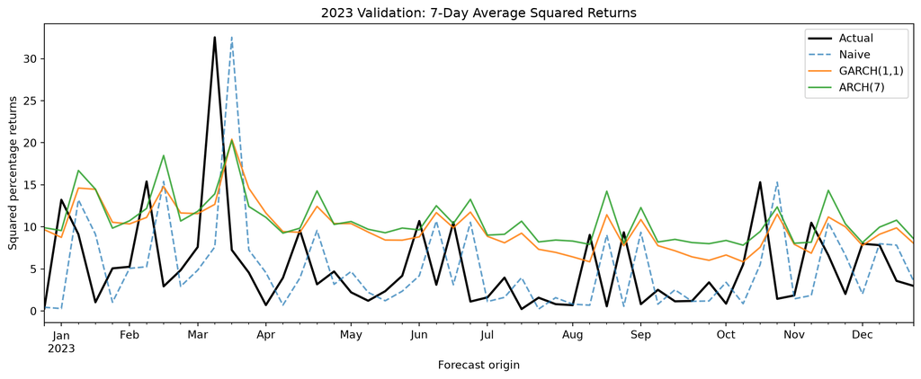

```python
import matplotlib.pyplot as plt

best_two = (
    validation_scores
    .drop(index="Naive")
    .nsmallest(2, "RMSE")
    .index.tolist()
)

fig, ax = plt.subplots(figsize=(12, 5))

scale = 10000

(validation_forecasts["actual"] * scale).plot(
    ax=ax,
    label="Actual",
    color="black",
    linewidth=2
)

(validation_forecasts["Naive"] * scale).plot(
    ax=ax,
    label="Naive",
    linestyle="--",
    alpha=0.7
)

for name in best_two:

    (validation_forecasts[name] * scale).plot(
        ax=ax,
        label=name,
        alpha=0.85
    )

ax.set_title("2023 Validation: 7-Day Average Squared Returns")
ax.set_ylabel("Squared percentage returns")
ax.set_xlabel("Forecast origin")
ax.legend()

plt.tight_layout()
plt.show()
```

Inspeacting the difference in errors and the plots, we actually see that the differences in performances across models was very small. We ran an exploratory Diebold-Mariano test to see if the RMSE difference between the Naive model and GARCH(1,1) was significant.

```python
import numpy as np
import pandas as pd
import statsmodels.api as sm

def dm_hac(forecasts, model_a, model_b,
           loss="squared", hac_lags=3):

    data = forecasts[
        ["actual", model_a, model_b]
    ].dropna().sort_index()

    # Rescale for numerical stability
    y = 1e4 * data["actual"].to_numpy()
    f_a = 1e4 * data[model_a].to_numpy()
    f_b = 1e4 * data[model_b].to_numpy()

    e_a = y - f_a
    e_b = y - f_b

    if loss == "squared":
        d = e_a**2 - e_b**2
    elif loss == "absolute":
        d = np.abs(e_a) - np.abs(e_b)
    else:
        raise ValueError("Unknown loss function")

    # Regression of loss differential on a constant
    X = np.ones((len(d), 1))

    result = sm.OLS(d, X).fit(
        cov_type="HAC",
        cov_kwds={
            "maxlags": hac_lags,
            "use_correction": True
        },
        use_t=True
    )

    return pd.Series({
        "N": len(d),
        "Mean loss difference": result.params[0],
        "Standard error": result.bse[0],
        "DM-HAC statistic": result.tvalues[0],
        "p-value": result.pvalues[0]
    })

dm_result = dm_hac(
    validation_forecasts,
    model_a="GARCH(1,1)",
    model_b="Naive",
    loss="squared",
    hac_lags=3
)

display(dm_result.to_frame("Result"))
```

|  | Result |
| --- | --- |
| N | 52.000000 |
| Mean loss difference | -1.372552 |
| Standard error | 12.161852 |
| DM-HAC statistic | -0.112857 |
| p-value | 0.910587 |

The DM test fails to reject the null hypothesis of the error difference being zero, so we do not have enough evidence to say that the GARCH(1,1) improvement in performance is non-zero. Again, this is just an obsservation and it does not change our decision to freeze GARCH(1,1). We recognize runign the test after seeing the validation results would have introduced selection bias, which is why we made the decision before making this remark.

## 3.4 Forecasting in unseen data

We finally come to running the forecast on the test period data. This time we compute prediction intervals as well via simulation of paths using the GARCH(1,1) forecasts. Using the GARCH(1,1) recursion equation, we simulated 10,000 seven day paths at each test origin, and then we use the 2.5% and 97.5% quantiles from the data to draw prediction intervals rather than confidence intervals.

| origin | target_end | actual | Naive | GARCH(1,1) | lower_95 | upper_95 |
| --- | --- | --- | --- | --- | --- | --- |
| 2023-12-31 | 2024-01-07 | 0.000788 | 0.000260 | 0.000711 | 0.000127 | 0.002097 |
| 2024-01-07 | 2024-01-14 | 0.001675 | 0.000788 | 0.000872 | 0.000164 | 0.002442 |
| 2024-01-14 | 2024-01-21 | 0.000276 | 0.001675 | 0.001447 | 0.000266 | 0.004313 |
| 2024-01-21 | 2024-01-28 | 0.000690 | 0.000276 | 0.000952 | 0.000178 | 0.002705 |
| 2024-01-28 | 2024-02-04 | 0.000178 | 0.000690 | 0.000938 | 0.000183 | 0.002703 |

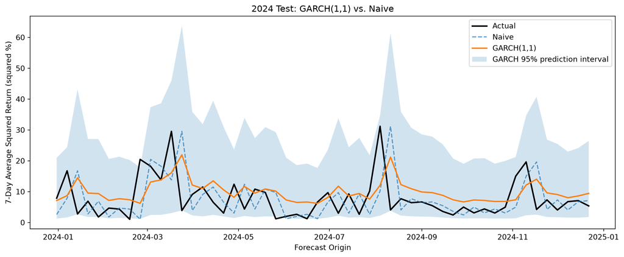

```python
import numpy as np
import pandas as pd
from arch import arch_model
import matplotlib.pyplot as plt
from sklearn.metrics import mean_absolute_error, mean_squared_error

train, validation, test = chronological_split(btc_full)

H = 7

# Forecast origins: December 31, 2023, then every seven days.
origins = pd.date_range(
    start=test.index.min() - pd.Timedelta(days=1),
    periods=len(test) // H,
    freq="7D"
)

records = []

for origin in origins:

    # Historical returns available at the forecast origin.
    history = (
        100 * btc_full.loc[:origin, "log_return"].dropna()
    )

    # Actual future target: next seven days.
    future = btc_full.loc[
        origin + pd.Timedelta(days=1):
        origin + pd.Timedelta(days=H),
        "squared_log_return"
    ]

    # Naive benchmark: previous seven days.
    past = btc_full.loc[
        origin - pd.Timedelta(days=H-1):
        origin,
        "squared_log_return"
    ]

    # Validate the forecast windows.
    assert len(future) == H and future.notna().all()
    assert len(past) == H and past.notna().all()

    assert future.index.min() >= test.index.min()
    assert future.index.max() <= test.index.max()

    # Fit the frozen GARCH(1,1) specification.
    model = arch_model(
        history,
        mean="Constant",
        vol="GARCH",
        p=1,
        q=1,
        dist="normal",
        hold_back=8,
        rescale=False
    )

    fit = model.fit(disp="off")

    if fit.convergence_flag != 0:
        raise RuntimeError(
            f"GARCH failed to converge at {origin}"
        )

    # Seven-day analytical forecast.
    fc = fit.forecast(
        horizon=H,
        method="analytic",
        reindex=False
    )

    mean_fc = fc.mean.iloc[-1].to_numpy()
    var_fc = fc.variance.iloc[-1].to_numpy()

    # Convert conditional moments to squared log returns.
    squared_fc = (var_fc + mean_fc**2) / 10000

    if not np.isfinite(squared_fc).all():
        raise ValueError(f"Invalid forecast at {origin}")

    records.append({
        "origin": origin,
        "target_end": future.index[-1],
        "actual": future.mean(),
        "Naive": past.mean(),
        "GARCH(1,1)": squared_fc.mean()
    })

test_forecasts = (
    pd.DataFrame(records)
    .set_index("origin")
)

B = 10000

rng = np.random.default_rng(546)

intervals = []

for origin in test_forecasts.index:

    # Historical information available at the forecast origin
    history = (
        100 * btc_full.loc[:origin, "log_return"].dropna()
    )

    # Frozen GARCH(1,1) specification
    model = arch_model(
        history,
        mean="Constant",
        vol="GARCH",
        p=1,
        q=1,
        dist="normal",
        hold_back=8,
        rescale=False
    )

    fit = model.fit(disp="off")

    if fit.convergence_flag != 0:
        raise RuntimeError(
            f"GARCH did not converge at {origin}"
        )

    # Simulate B possible paths over the next H days
    fc = fit.forecast(
        horizon=H,
        method="simulation",
        simulations=B,
        rng=rng.standard_normal,
        reindex=False
    )

    # Simulated future returns in percentage units
    simulated_returns = fc.simulations.values[-1]

    assert simulated_returns.shape == (B, H)

    # Compute our target for each simulated path
    simulated_targets = (
        np.mean(simulated_returns**2, axis=1) / 10000
    )

    # Equal-tailed 95% prediction interval
    lower, upper = np.quantile(
        simulated_targets,
        [0.025, 0.975]
    )

    intervals.append({
        "origin": origin,
        "lower_95": lower,
        "upper_95": upper
    })

intervals = pd.DataFrame(intervals).set_index("origin")

test_forecasts_ci = test_forecasts.join(intervals)

display(test_forecasts_ci.head())

scale = 10000

fig, ax = plt.subplots(figsize=(12, 5))

# Observed 7-day average squared returns
ax.plot(
    test_forecasts_ci.index,
    scale * test_forecasts_ci["actual"],
    label="Actual",
    color="black",
    linewidth=2
)

# Naive benchmark
ax.plot(
    test_forecasts_ci.index,
    scale * test_forecasts_ci["Naive"],
    label="Naive",
    linestyle="--",
    alpha=0.7
)

# GARCH(1,1) point forecast
ax.plot(
    test_forecasts_ci.index,
    scale * test_forecasts_ci["GARCH(1,1)"],
    label="GARCH(1,1)",
    linewidth=1.8
)

# Simulation-based 95% prediction interval
ax.fill_between(
    test_forecasts_ci.index,
    scale * test_forecasts_ci["lower_95"],
    scale * test_forecasts_ci["upper_95"],
    alpha=0.2,
    label="GARCH 95% prediction interval"
)

ax.set_title(
    "2024 Test: GARCH(1,1) vs. Naive"
)

ax.set_ylabel("7-Day Average Squared Return (squared %)")
ax.set_xlabel("Forecast Origin")

ax.legend()

plt.tight_layout()
plt.show()
```

We measure how many times does the actual seven-day mean falls out of the prediction intervals:

```python
actual = test_forecasts_ci["actual"]

lower = test_forecasts_ci["lower_95"]
upper = test_forecasts_ci["upper_95"]

inside = (actual >= lower) & (actual <= upper)

coverage = inside.mean()

below = (actual < lower).sum()
above = (actual > upper).sum()

average_width = (upper - lower).mean()

interval_results = pd.DataFrame({
    "Metric": [
        "Nominal coverage",
        "Empirical coverage",
        "Observations inside",
        "Observations below",
        "Observations above",
        "Average interval width (x1e4)"
    ],
    "Value": [
        0.95,
        coverage,
        inside.sum(),
        below,
        above,
        10000 * average_width
    ]
})

display(interval_results)
```

|  | Metric | Value |
| --- | --- | --- |
| 0 | Nominal coverage | 0.950000 |
| 1 | Empirical coverage | 0.884615 |
| 2 | Observations inside | 46.000000 |
| 3 | Observations below | 5.000000 |
| 4 | Observations above | 1.000000 |
| 5 | Average interval width (x1e4) | 26.729853 |

We expected 95% of the observation to be within the intervals, but only 88% of the actual observations fell within the bounds. This could be due to several reasons, but one that comes to mind is that we only had 52 observations, which is not a big sample size and so it potentially is very noisy.

Now, with regards to actual performance:

```python
rows = []

for name in ["Naive", "GARCH(1,1)"]:

    actual = test_forecasts["actual"]
    predicted = test_forecasts[name]

    mae = mean_absolute_error(actual, predicted)
    rmse = np.sqrt(mean_squared_error(actual, predicted))

    rows.append({
        "Model": name,
        "MAE": mae,
        "RMSE": rmse,
        "MAE (x1e4)": mae * 10000,
        "RMSE (x1e4)": rmse * 10000
    })

test_scores = (
    pd.DataFrame(rows)
    .set_index("Model")
    .sort_values("RMSE")
)

display(test_scores.round(6))
```

| Model | MAE | RMSE | MAE (x1e4) | RMSE (x1e4) |
| --- | --- | --- | --- | --- |
| GARCH(1,1) | 0.000551 | 0.00071 | 5.508137 | 7.101402 |
| Naive | 0.000591 | 0.00086 | 5.905032 | 8.596143 |

Observing these results we see that the GARCH(1,1) model generalized better to the test-period data and it beat the baseline in both MAE and RMSE, thought by very small amounts. We run the DM test on the squared errors to see if this difference is significative.

```python
dm_test = dm_hac(
    test_forecasts,
    model_a="GARCH(1,1)",
    model_b="Naive",
    loss="squared",
    hac_lags=3
)

display(dm_test.to_frame("Test Result"))
```

|  | Test Result |
| --- | --- |
| N | 52.000000 |
| Mean loss difference | -23.463761 |
| Standard error | 11.997941 |
| DM-HAC statistic | -1.955649 |
| p-value | 0.055996 |

The test shies away from rejecting the null by a very small quantity, but at the 5% significance level, we do not have statistical evidence to say this difference is non-zero.

This completes the pipeline for classical statistical models, and now we move forward to forecasting using tree based methods.

# 4. Tree-Based Methods Forecasting

## 4.1 Feature engineering

Machine learning models estimate the target directly, so our goal here is rather to construct features to feed into the models, and then let the models find the non-linear relationships themselves. Our research goal now is also to distinguish if including features coming from on-chain data from BTC helps predict the seven day mean.

For this purpose we build two main sets of features: one that we call the market features:

- Current log return $r_t$
- Absolute log return $|r_t|$
- Squared log return $v_t$
- Trailing means of $v_t$ over 7, 14 and 30 days;
- Trailing seven day cumulative log return
- Same day $\log(H_t/L_t)$, where $H_t$ is the high and $L_t$ is the low price on day $t$
- $\log(1 + Vol_t)$, where $Vol_t$ is the trading volume
- The deviation of $\log(1 + Vol_t)$ with its seven day mean

These makes for a total of 10 market-only features. Most of these were at the suggestion of AI, but they are also economically motivated. Using the return and the squared returns makes sense, since these quantities are directly related to what we are trying to forecast. The absolute log return is a notion of size of the return, while the trailing means of the squared log returns smooth out the trajectory of the squared log returns using different timeframes, making it useful to identify short term (7 days), medium term (14 days) and long term (30 days) patterns, so these measure some sort of momentum of the data. The difference of $\log(1 + Vol_t)$ with its seven day mean is a similar measure, how much has the volume changed over the previous week. We add a one and take the log since volume could in theory be zero, adn we take logs so that multiplicative trends become additive, and the difference with the mean should make this series somewhat more stationary intuitively, though we do not claim it is. Same day log high over low is again the same sort of concept, but intraday, how much did the price fluctuate from its lowest to its highest within each day.

The requirements for some of these quantities require us to rebuild the training, validation and test dataframes, particularly because, for example for the 30 day rolling mean, we need to use the first 30 days to produce the first value for the rolling mean, so if our training data began on January 1, 2020, it should now begin on January 31, 2020, since only then the 30 day rolling mean first becomes available.

We also have a second set of features on top of the market features, which we call the on-chain features, which are

- Seven day lagged mining difficulty $d_{t-7}$
- Seven day lagged hash rate $hr_{t-7}$
- Seven day lagged transaction fees in BTC $f_{t-7}$

All of these are available at the forecast origin $t$. We construct the new data frame, and we add one final column whose values are the forecast target, the seven-day mean of the squared log returns.

```python
btc_ml = btc_full.copy()

r = btc_ml["log_return"]
v = btc_ml["squared_log_return"]

ml_data = pd.DataFrame(index=btc_ml.index)

# Market features
ml_data["r_t"] = r
ml_data["abs_r_t"] = r.abs()
ml_data["v_t"] = v

ml_data["rv_7"] = v.rolling(7).mean()
ml_data["rv_14"] = v.rolling(14).mean()
ml_data["rv_30"] = v.rolling(30).mean()

ml_data["return_7"] = r.rolling(7).sum()

ml_data["range_t"] = np.log(
    btc_ml["High"] / btc_ml["Low"]
)

ml_data["log_volume"] = np.log1p(btc_ml["Volume"])

ml_data["volume_change_7"] = (
    ml_data["log_volume"]
    - ml_data["log_volume"].rolling(7).mean()
)

# On-chain features
onchain_features = [
    "hash_rate_lag7",
    "difficulty_lag7",
    "fees_btc_lag7"
]

ml_data[onchain_features] = btc_ml[onchain_features]

# Direct seven-day forward target
H = 7

ml_data["target_7"] = (
    sum(v.shift(-h) for h in range(1, H + 1)) / H
)

market_features = [
    "r_t",
    "abs_r_t",
    "v_t",
    "rv_7",
    "rv_14",
    "rv_30",
    "return_7",
    "range_t",
    "log_volume",
    "volume_change_7"
]

# Remove rows with incomplete predictors or targets
ml_data = ml_data.dropna(
    subset=market_features + onchain_features + ["target_7"]
)

display(ml_data.head())
```

| time | r_t | abs_r_t | v_t | rv_7 | rv_14 | rv_30 | return_7 | range_t | log_volume | volume_change_7 | hash_rate_lag7 | difficulty_lag7 | fees_btc_lag7 | target_7 |
| --- | --- | --- | --- | --- | --- | --- | --- | --- | --- | --- | --- | --- | --- | --- |
| 2020-01-31 | -0.016805 | 0.016805 | 0.000282 | 0.000747 | 0.000514 | 0.000840 | 0.101807 | 0.031031 | 24.105365 | 0.060184 | 1.116497e+08 | 1.477637e+13 | 16.100824 | 0.000362 |
| 2020-02-01 | 0.004518 | 0.004518 | 0.000020 | 0.000738 | 0.000515 | 0.000810 | 0.115555 | 0.013447 | 23.978383 | -0.106394 | 1.204641e+08 | 1.477637e+13 | 11.393263 | 0.000366 |
| 2020-02-02 | -0.005178 | 0.005178 | 0.000027 | 0.000637 | 0.000466 | 0.000727 | 0.083380 | 0.026863 | 24.151940 | 0.020078 | 1.050388e+08 | 1.477637e+13 | 10.572991 | 0.000453 |
| 2020-02-03 | -0.005456 | 0.005456 | 0.000030 | 0.000459 | 0.000465 | 0.000725 | 0.042164 | 0.031057 | 24.155125 | 0.012292 | 9.475530e+07 | 1.477637e+13 | 19.787175 | 0.000546 |
| 2020-02-04 | -0.012185 | 0.012185 | 0.000148 | 0.000135 | 0.000469 | 0.000730 | -0.019163 | 0.023689 | 24.120896 | -0.001881 | 1.073215e+08 | 1.520381e+13 | 22.987378 | 0.000700 |

## 4.2 Models and Hyperparameter tuning

Because we wanted to use tree based models, the two natural models that come to mind were Random Forest and XGBoost. These do different tasks, random forests run several trees and then average the results for better predictions, while XGBoost runs trees sequentially and learns which trees perform better.

Each of these models contain hyperparemeters that affect the models performance, so before choosing a particular set of features and fitting the models to those, we first perform cross-validation during the training period to select hyperparameters.

We first ran a grid search over AI suggested values for cross validation, though this search was only preliminary and not the final tuning methodology. We did the grid search in the training period, which we split into four folds using `TimeSeriesSplit`, each block had 91 days, and a seven day observation gap. Each successive fold expanded its training history.

```python
import numpy as np
import pandas as pd

from sklearn.model_selection import TimeSeriesSplit, GridSearchCV
from sklearn.metrics import make_scorer
from sklearn.ensemble import RandomForestRegressor

from xgboost import XGBRegressor

H = 7

# Only use training examples whose entire target window
# falls within the original training period.
train_end = train.index.max()

training_ml = ml_data.loc[
    train.index.min():train_end - pd.Timedelta(days=H)
].copy()

training_ml = training_ml.sort_index()

# Verify that the observations are consecutive daily dates.
assert (
    training_ml.index.to_series()
    .diff()
    .dropna()
    .eq(pd.Timedelta(days=1))
    .all()
)

print("Training observations:", len(training_ml))
print("First origin:", training_ml.index.min())
print("Last origin:", training_ml.index.max())

tscv = TimeSeriesSplit(
    n_splits=4,
    test_size=91,
    gap=H
)

cv_splits = []

fold_info = []

for fold, (train_idx, val_idx) in enumerate(
    tscv.split(training_ml), start=1
):

    # Weekly-spaced validation origins.
    weekly_idx = val_idx[::H]

    # Require the full 7-day target to remain
    # within this validation block.
    weekly_idx = weekly_idx[
        weekly_idx + H <= val_idx[-1]
    ]

    cv_splits.append((train_idx, weekly_idx))

    fold_info.append({
        "Fold": fold,
        "Training end": training_ml.index[train_idx[-1]],
        "Validation start": training_ml.index[weekly_idx[0]],
        "Validation end": training_ml.index[weekly_idx[-1]],
        "Weekly forecasts": len(weekly_idx)
    })

display(pd.DataFrame(fold_info))
```

```
Training observations: 1059
First origin: 2020-01-31 00:00:00
Last origin: 2022-12-24 00:00:00
```

|  | Fold | Training end | Validation start | Validation end | Weekly forecasts |
| --- | --- | --- | --- | --- | --- |
| 0 | 1 | 2021-12-18 | 2021-12-26 | 2022-03-13 | 12 |
| 1 | 2 | 2022-03-19 | 2022-03-27 | 2022-06-12 | 12 |
| 2 | 3 | 2022-06-18 | 2022-06-26 | 2022-09-11 | 12 |
| 3 | 4 | 2022-09-17 | 2022-09-25 | 2022-12-11 | 12 |

The objective for tuning was to maximized negative mean squared error.

```python
def negative_mse_clipped(y_true, y_pred):

    y_pred = np.maximum(y_pred, 0.0)

    return -np.mean((y_true - y_pred)**2)


mse_scorer = make_scorer(
    negative_mse_clipped,
    greater_is_better=True
)
```

The parameters used in the grid search were chosen by AI (see AI log). We did not think this was a systematic approach and seemed rather arbitrary, so once again, this was not our final methodology. However, we keep this part of the process for transparency and because we observed abaltion results from these parameters before we switched to a better approach.

The grid used the following values only for certain parameters

```python
rf_base = RandomForestRegressor(
    n_estimators=300,
    random_state=42,
    n_jobs=-1
)

rf_grid = {
    "max_depth": [4, 5, 7],
    "min_samples_leaf": [5, 10, 20],
    "max_features": [0.8, 1.0]
}


xgb_base = XGBRegressor(
    objective="reg:squarederror",
    subsample=0.8,
    colsample_bytree=0.8,
    reg_lambda=1.0,
    tree_method="hist",
    random_state=42,
    n_jobs=4
)

xgb_grid = {
    "n_estimators": [150, 300],
    "max_depth": [2, 3],
    "learning_rate": [0.03, 0.07],
    "min_child_weight": [1, 10]
}


model_grids = {
    "RF": (rf_base, rf_grid),
    "XGBoost": (xgb_base, xgb_grid)
}

feature_sets = {
    "Market": market_features,
    "Market + On-chain": market_features + onchain_features
}
```

Which we can now run the search on:

```python
grid_searches = {}

grid_results = []

y_train = 10000 * training_ml["target_7"]

for model_name, (estimator, param_grid) in model_grids.items():

    for feature_name, features in feature_sets.items():

        print(f"Grid search: {model_name} - {feature_name}")

        X_train = training_ml[features]

        search = GridSearchCV(
            estimator=estimator,
            param_grid=param_grid,
            scoring=mse_scorer,
            cv=cv_splits,
            refit=False,
            n_jobs=1,
            verbose=0
        )

        search.fit(X_train, y_train)

        grid_searches[(model_name, feature_name)] = search

        grid_results.append({
            "Model": model_name,
            "Features": feature_name,
            "CV RMSE (x1e4)": np.sqrt(
                -search.best_score_
            ),
            "Best parameters": search.best_params_
        })

grid_summary = pd.DataFrame(grid_results)

display(grid_summary)
```

```
Grid search: RF - Market
Grid search: RF - Market + On-chain
Grid search: XGBoost - Market
Grid search: XGBoost - Market + On-chain
```

|  | Model | Features | CV RMSE (x1e4) | Best parameters |
| --- | --- | --- | --- | --- |
| 0 | RF | Market | 14.517461 | {'max_depth': 5, 'max_features': 1.0, 'min_sam... |
| 1 | RF | Market + On-chain | 15.932578 | {'max_depth': 4, 'max_features': 0.8, 'min_sam... |
| 2 | XGBoost | Market | 15.040756 | {'learning_rate': 0.03, 'max_depth': 3, 'min_c... |
| 3 | XGBoost | Market + On-chain | 15.266610 | {'learning_rate': 0.03, 'max_depth': 2, 'min_c... |

We did not use this results to choose parameters to move into the validation set. Rather, at this stage we froze the chosen hyperparameters for the RF - Market + On Chain feature set and we ran the ablation studies. It is worth noting that we also coded here an helper to use it for the validation forecasting process, where we now went want back to expanding window validation. It was an expanding window with 52 origins, and at each origin a new model was fitted, and then the next seven days mean was predicted. We used this same forecasting methodology later for our finalized forecast.

```python
from itertools import combinations
from sklearn.base import clone

def expanding_ml_forecasts(
    estimator,
    data,
    features,
    origins,
    horizon=7
):

    predictions = []

    for origin in origins:

        # The final admissible training origin is t-H.
        cutoff = origin - pd.Timedelta(days=horizon)

        history = data.loc[
            data.index <= cutoff
        ]

        X_train = history[features]
        y_train = 10000 * history["target_7"]

        X_forecast = data.loc[[origin], features]

        fitted = clone(estimator)

        fitted.fit(X_train, y_train)

        forecast = fitted.predict(X_forecast)[0]

        # Enforce nonnegative forecasts.
        forecast = max(float(forecast), 0.0)

        predictions.append(forecast / 10000)

    return pd.Series(
        predictions,
        index=origins,
        name="forecast"
    )

def forecasting_scores(
    forecasts,
    actual_col="actual"
):

    actual = forecasts[actual_col]

    rows = []

    for name in forecasts.columns.drop(actual_col):

        predicted = forecasts[name]

        rows.append({
            "Model": name,
            "MAE (x1e4)": 10000 * mean_absolute_error(
                actual, predicted
            ),
            "RMSE (x1e4)": 10000 * np.sqrt(
                mean_squared_error(actual, predicted)
            )
        })

    return (
        pd.DataFrame(rows)
        .set_index("Model")
        .sort_values("RMSE (x1e4)")
    )

tuned_models = {}

for (model_name, feature_name), search in grid_searches.items():

    base_model = model_grids[model_name][0]

    tuned_models[(model_name, feature_name)] = (
        clone(base_model).set_params(**search.best_params_)
    )

validation_origins = validation_forecasts.index

tuned_validation = validation_forecasts[
    ["actual", "Naive", "GARCH(1,1)"]
].copy()

for (model_name, feature_name), estimator in tuned_models.items():

    name = f"{model_name} - {feature_name}"

    tuned_validation[name] = expanding_ml_forecasts(
        estimator=estimator,
        data=ml_data,
        features=feature_sets[feature_name],
        origins=validation_origins,
        horizon=H
    )

ablation_sets = {}

for k in range(len(onchain_features) + 1):

    for subset in combinations(onchain_features, k):

        if len(subset) == 0:
            name = "Market only"
        else:
            name = " + ".join(subset)

        ablation_sets[name] = (
            market_features + list(subset)
        )

print("Number of ablation configurations:", len(ablation_sets))

# Use the RF hyperparameters selected for all on-chain variables.
rf_ablation_model = tuned_models[
    ("RF", "Market + On-chain")
]

ablation_forecasts = validation_forecasts[
    ["actual"]
].copy()

for name, features in ablation_sets.items():

    print(f"Ablation: {name}")

    ablation_forecasts[name] = expanding_ml_forecasts(
        estimator=rf_ablation_model,
        data=ml_data,
        features=features,
        origins=validation_origins,
        horizon=H
    )

ablation_scores = forecasting_scores(
    ablation_forecasts
)

display(ablation_scores.round(4))
```

```
Number of ablation configurations: 8
Ablation: Market only
Ablation: hash_rate_lag7
Ablation: difficulty_lag7
Ablation: fees_btc_lag7
Ablation: hash_rate_lag7 + difficulty_lag7
Ablation: hash_rate_lag7 + fees_btc_lag7
Ablation: difficulty_lag7 + fees_btc_lag7
Ablation: hash_rate_lag7 + difficulty_lag7 + fees_btc_lag7
```

| Model | MAE (x1e4) | RMSE (x1e4) |
| --- | --- | --- |
| difficulty_lag7 | 4.9820 | 6.4620 |
| difficulty_lag7 + fees_btc_lag7 | 5.0087 | 6.4806 |
| hash_rate_lag7 + difficulty_lag7 | 5.0561 | 6.5677 |
| hash_rate_lag7 + difficulty_lag7 + fees_btc_lag7 | 5.0949 | 6.5783 |
| hash_rate_lag7 + fees_btc_lag7 | 5.2720 | 6.7880 |
| hash_rate_lag7 | 5.2657 | 6.8088 |
| fees_btc_lag7 | 5.4482 | 6.9437 |
| Market only | 5.4657 | 7.0195 |

The grid searach was deliberately small for computational efficiency, but it was not a fully thorough and systematic way to tune the models. We moved forward instead using random search cross validation over 24 iterations. This allowed to expand the search of the parameters while still being computationally feasible.

The one thing we extracted from this preliminary search was that the ablation studies indicated the mining difficulty feature improved validation scores. The way the ablation test was done was to use the chosen hyperparameters for RF- Market + On Chain, and use those to forecast in the validation period using all different subsets of combinations of the on-chain features. We used this then as a diagnostic to consider a feature configuration considering market plus difficulty only features. We also note that the ablation was only done for Random Forest models. Due to time we didn’t have the occassion to run the experiments for XGBoost.

We now turn to the randomized search approach.

The idea now is to first manually create the CV folds out of extra care, and to be more explicit about the train/validation blocks. We used now four folds, April 2021 - June 2021, October 2021 - December 2021, April 2022 - June 2022 and October 2022 - December 2022. Then, we used `RandomizedSearchCV` with 24 iterations. We then specified larger spaces for hyperparameters that the algorithm now samples at random and returns the best performing one with respect to maximizing the negative squared error.

```python
import numpy as np
import pandas as pd

H = 7

# Restrict all hyperparameter tuning to 2020–2022.
# The final seven training origins must be excluded
# because their targets are not fully observable in 2022.
training_ml = ml_data.loc[
    train.index.min():
    train.index.max() - pd.Timedelta(days=H)
].sort_index().copy()

fold_periods = [
    ("2021-04-01", "2021-06-30"),
    ("2021-10-01", "2021-12-31"),
    ("2022-04-01", "2022-06-30"),
    ("2022-10-01", "2022-12-24")
]

cv_splits = []
fold_summary = []

for fold, (start, end) in enumerate(fold_periods, start=1):

    start = pd.Timestamp(start)
    end = pd.Timestamp(end)

    # Training labels must be fully known at
    # the first forecast origin.
    cutoff = start - pd.Timedelta(days=H)

    train_idx = np.flatnonzero(
        training_ml.index <= cutoff
    )

    # Weekly forecast origins with complete targets
    # inside the validation interval.
    weekly_dates = pd.date_range(
        start=start,
        end=end - pd.Timedelta(days=H),
        freq="7D"
    )

    val_idx = training_ml.index.get_indexer(weekly_dates)

    assert len(train_idx) > 0
    assert (val_idx >= 0).all()
    assert train_idx[-1] < val_idx[0]

    cv_splits.append((train_idx, val_idx))

    fold_summary.append({
        "Fold": fold,
        "Train start": training_ml.index[train_idx[0]],
        "Train end": training_ml.index[train_idx[-1]],
        "Validation start": training_ml.index[val_idx[0]],
        "Validation end": training_ml.index[val_idx[-1]],
        "Training samples": len(train_idx),
        "Weekly forecasts": len(val_idx)
    })

display(pd.DataFrame(fold_summary))
```

|  | Fold | Train start | Train end | Validation start | Validation end | Training samples | Weekly forecasts |
| --- | --- | --- | --- | --- | --- | --- | --- |
| 0 | 1 | 2020-01-31 | 2021-03-25 | 2021-04-01 | 2021-06-17 | 420 | 12 |
| 1 | 2 | 2020-01-31 | 2021-09-24 | 2021-10-01 | 2021-12-24 | 603 | 13 |
| 2 | 3 | 2020-01-31 | 2022-03-25 | 2022-04-01 | 2022-06-17 | 785 | 12 |
| 3 | 4 | 2020-01-31 | 2022-09-24 | 2022-10-01 | 2022-12-17 | 968 | 12 |

The state space for the search is now the following:

```python
from sklearn.model_selection import RandomizedSearchCV
from sklearn.ensemble import RandomForestRegressor
from sklearn.metrics import make_scorer
from sklearn.base import clone
from xgboost import XGBRegressor

rf_base = RandomForestRegressor(
    n_estimators=300,
    random_state=42,
    n_jobs=-1
)

rf_search_space = {
    "max_depth": [3, 5, 7, 10, None],
    "min_samples_leaf": [5, 10, 20, 40],
    "max_features": [0.6, 0.8, 1.0]
}

xgb_base = XGBRegressor(
    objective="reg:squarederror",
    tree_method="hist",
    random_state=42,
    n_jobs=4
)

xgb_search_space = {
    "n_estimators": [100, 200, 400],
    "max_depth": [2, 3, 4],
    "learning_rate": [0.02, 0.04, 0.08, 0.12],
    "min_child_weight": [1, 5, 10, 20],
    "subsample": [0.7, 0.85, 1.0],
    "colsample_bytree": [0.7, 0.85, 1.0],
    "reg_lambda": [0.3, 1.0, 3.0, 10.0]
}
```

We still are not varying a large amount of values, but this is a more principled way of tuning parameters. We did not run any additional searches after this one to prevent risks of overfitting. As mentioned before, from the preliminary ablation we consider only the following five feature configurations, where the new addition is to consider a random forest with market features plus lagged mining difficulty.

```python
search_specs = {
    "RF - Market": (
        rf_base,
        rf_search_space,
        market_features
    ),

    "RF - Market + Difficulty": (
        rf_base,
        rf_search_space,
        market_features + ["difficulty_lag7"]
    ),

    "RF - Market + On-chain": (
        rf_base,
        rf_search_space,
        market_features + onchain_features
    ),

    "XGBoost - Market": (
        xgb_base,
        xgb_search_space,
        market_features
    ),

    "XGBoost - Market + On-chain": (
        xgb_base,
        xgb_search_space,
        market_features + onchain_features
    )
}
```

The final search returned the following CV scores.

```python
def negative_mse_clipped(y_true, y_pred):
    y_pred = np.maximum(y_pred, 0.0)
    return -np.mean((y_true - y_pred)**2)

mse_scorer = make_scorer(
    negative_mse_clipped,
    greater_is_better=True
)

final_searches = {}
final_estimators = {}
rows = []

y_cv = 10000 * training_ml["target_7"]

for name, (base, space, features) in search_specs.items():

    print(f"Searching: {name}")

    search = RandomizedSearchCV(
        estimator=base,
        param_distributions=space,
        n_iter=24,
        scoring=mse_scorer,
        cv=cv_splits,
        random_state=546,
        n_jobs=1,
        refit=False,
        verbose=0,
        error_score="raise"
    )

    search.fit(training_ml[features], y_cv)

    final_searches[name] = search

    final_estimators[name] = (
        clone(base).set_params(**search.best_params_)
    )

    rows.append({
        "Model": name,
        "CV RMSE (x1e4)": np.sqrt(-search.best_score_),
        **search.best_params_
    })

final_search_summary = (
    pd.DataFrame(rows)
    .set_index("Model")
    .sort_values("CV RMSE (x1e4)")
)

display(final_search_summary)
```

```
Searching: RF - Market
Searching: RF - Market + Difficulty
Searching: RF - Market + On-chain
Searching: XGBoost - Market
Searching: XGBoost - Market + On-chain
```

| Model | CV RMSE (x1e4) | min_samples_leaf | max_features | max_depth | subsample | reg_lambda | n_estimators | min_child_weight | learning_rate | colsample_bytree |
| --- | --- | --- | --- | --- | --- | --- | --- | --- | --- | --- |
| RF - Market + Difficulty | 14.150029 | 10.0 | 0.6 | NaN | NaN | NaN | NaN | NaN | NaN | NaN |
| RF - Market | 14.738300 | 20.0 | 0.8 | NaN | NaN | NaN | NaN | NaN | NaN | NaN |
| XGBoost - Market + On-chain | 14.939657 | NaN | NaN | 2.0 | 0.7 | 10.0 | 100.0 | 1.0 | 0.02 | 0.7 |
| RF - Market + On-chain | 15.153545 | 10.0 | 0.8 | 3.0 | NaN | NaN | NaN | NaN | NaN | NaN |
| XGBoost - Market | 15.565879 | NaN | NaN | 2.0 | 0.7 | 10.0 | 100.0 | 1.0 | 0.02 | 0.7 |

We also report the performance of each model on the validation period data:

```python
final_validation = validation_forecasts[
    ["actual", "Naive", "GARCH(1,1)"]
].copy()

for name, estimator in final_estimators.items():

    features = search_specs[name][2]

    final_validation[name] = expanding_ml_forecasts(
        estimator=estimator,
        data=ml_data,
        features=features,
        origins=validation_forecasts.index,
        horizon=7
    )

final_validation_scores = forecasting_scores(
    final_validation
)

display(final_validation_scores.round(4))
```

| Model | MAE (x1e4) | RMSE (x1e4) |
| --- | --- | --- |
| RF - Market + On-chain | 4.7446 | 5.8931 |
| RF - Market + Difficulty | 4.6289 | 6.0023 |
| RF - Market | 4.8724 | 6.1426 |
| XGBoost - Market + On-chain | 5.4373 | 6.4551 |
| GARCH(1,1) | 6.4468 | 7.4586 |
| XGBoost - Market | 6.0173 | 7.4689 |
| Naive | 5.2964 | 7.5500 |

The randomized search CV RMSE showed Random Forest with Market and Difficulty features won, but on the validation period with the hyperparameters chosen on training, Random Forest with full market and on-chain features was the winner in RMSE, even winning against GARCH(1,1) and the Naive baseline. From the machine learning models, XGBoost with full market features was the worst performer, though we do note that the differences in RMSE were small. At this stage we freeze hyperparameters and we can move on to the final forecasting test.

Because we are interested in answering the question of whether the on-chain variables help or not, we will actually test the RF- Market + On Chain vs RF - Market Only, and XGBoost - Market + On=chain vs XGBoost - Market Only. We drop Market + Difficulty since full on-chain generalized better in validation.

# 5 Final Comparisons and Forecasts

## 5.1 Out-of-sample results

After validation, we freeze the hyperparameters learned from training, as well as the selected models.

```python
frozen_names = [
    "RF - Market",
    "RF - Market + On-chain",
    "XGBoost - Market",
    "XGBoost - Market + On-chain"
]

frozen_models = {
    name: final_estimators[name]
    for name in frozen_names
}

frozen_features = {
    name: list(search_specs[name][2])
    for name in frozen_names
}

# Reuse the 52 weekly test origins from GARCH evaluation
test_origins = test_forecasts.index

final_ml_test = test_forecasts[
    ["actual", "Naive", "GARCH(1,1)"]
].copy()

for name in frozen_names:

    print(f"Evaluating: {name}")

    final_ml_test[name] = expanding_ml_forecasts(
        estimator=frozen_models[name],
        data=ml_data,
        features=frozen_features[name],
        origins=test_origins,
        horizon=7
    )

# Verify the same targets are used
assert len(final_ml_test) == 52

assert np.allclose(
    final_ml_test["actual"],
    ml_data.loc[test_origins, "target_7"]
)

final_ml_scores = forecasting_scores(final_ml_test)

naive_rmse = final_ml_scores.loc[
    "Naive", "RMSE (x1e4)"
]

final_ml_scores["RMSE improvement (%)"] = (
    100 * (
        naive_rmse - final_ml_scores["RMSE (x1e4)"]
    ) / naive_rmse
)

display(final_ml_scores.round(4))
```

```
Evaluating: RF - Market
Evaluating: RF - Market + On-chain
Evaluating: XGBoost - Market
Evaluating: XGBoost - Market + On-chain
```

| Model | MAE (x1e4) | RMSE (x1e4) | RMSE improvement (%) |
| --- | --- | --- | --- |
| XGBoost - Market + On-chain | 4.9813 | 6.3872 | 25.6974 |
| RF - Market + On-chain | 4.7061 | 6.4265 | 25.2401 |
| XGBoost - Market | 5.5739 | 6.8757 | 20.0141 |
| GARCH(1,1) | 5.5081 | 7.1014 | 17.3885 |
| RF - Market | 6.2471 | 8.4211 | 2.0365 |
| Naive | 5.9050 | 8.5961 | 0.0000 |

The model with the smallest RMSE was XGBoost with full market and on-chain features, performing about 25% better than the naive baseline. Random forests with full on-chain is on second with about the same gain from the baseline. Every model beat the baseline, but the machine learning models with only market features only did not do as well, and in fact GARCH(1,1) performs comparatively better than random forests with market features only.

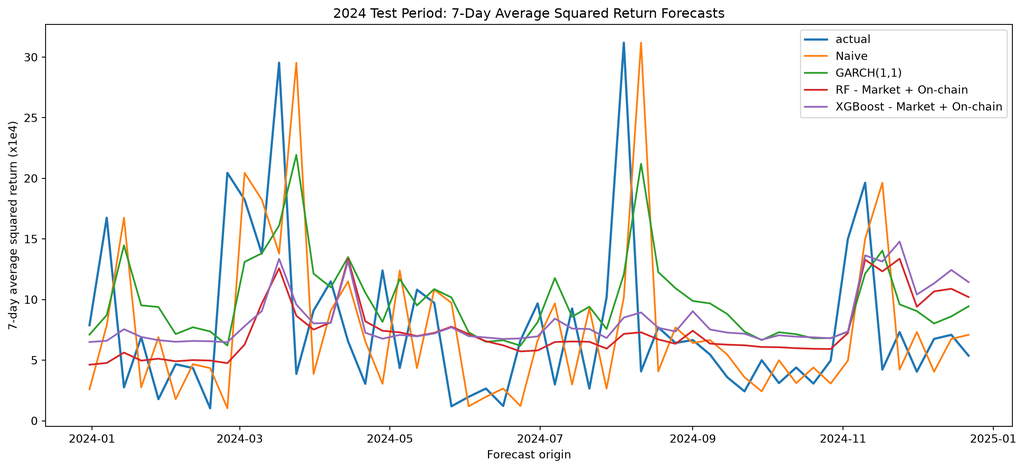

```python
import matplotlib.pyplot as plt

scale = 10000  # show squared-percentage-return units

plot_cols = [
    "actual",
    "Naive",
    "GARCH(1,1)",
    "RF - Market + On-chain",
    "XGBoost - Market + On-chain"
]

fig, ax = plt.subplots(figsize=(13, 6))

for col in plot_cols:
    ax.plot(
        final_ml_test.index,
        scale * final_ml_test[col],
        label=col,
        linewidth=2 if col == "actual" else 1.6
    )

ax.set_title("2024 Test Period: 7-Day Average Squared Return Forecasts")
ax.set_ylabel("7-day average squared return (x1e4)")
ax.set_xlabel("Forecast origin")
ax.legend()
plt.tight_layout()
plt.show()
```

For completeness we present a few more plots: first the forecasting errors and plot of the test performance by RMSE.

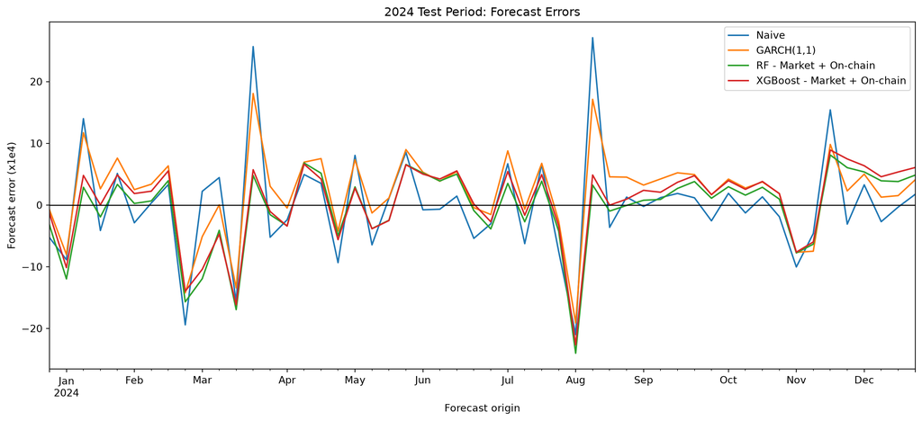

```python
error_cols = [
    "Naive",
    "GARCH(1,1)",
    "RF - Market + On-chain",
    "XGBoost - Market + On-chain",
]

errors_test = pd.DataFrame(index=final_ml_test.index)

for col in error_cols:
    errors_test[col] = 10000 * (final_ml_test[col] - final_ml_test["actual"])

fig, ax = plt.subplots(figsize=(13, 6))

errors_test.plot(ax=ax)
ax.axhline(0, color="black", linewidth=1)
ax.set_title("2024 Test Period: Forecast Errors")
ax.set_ylabel("Forecast error (x1e4)")
ax.set_xlabel("Forecast origin")
plt.tight_layout()
plt.show()
```

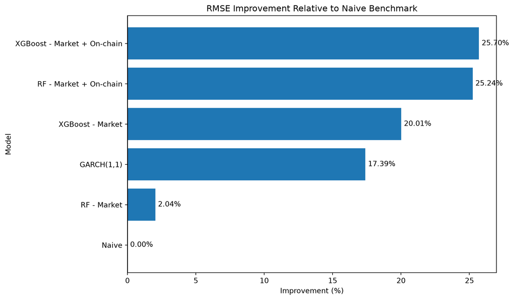

```python
improvement_plot = final_ml_scores.copy().sort_values("RMSE improvement (%)", ascending=True)

fig, ax = plt.subplots(figsize=(10, 6))

ax.barh(improvement_plot.index, improvement_plot["RMSE improvement (%)"])
ax.axvline(0, color="black", linewidth=1)
ax.set_title("RMSE Improvement Relative to Naive Benchmark")
ax.set_xlabel("Improvement (%)")
ax.set_ylabel("Model")

for i, value in enumerate(improvement_plot["RMSE improvement (%)"]):
    ax.text(value + 0.2, i, f"{value:.2f}%", va="center")

plt.tight_layout()
plt.show()
```

We measure the Diebold-Mariano statistic to see if the differences are significant.

```python
import numpy as np
import pandas as pd
import statsmodels.api as sm
from scipy import stats

def dm_hac(
    forecasts,
    model_a,
    model_b,
    loss="squared",
    hac_lags=3,
    scale=10000
):
    """
    Diebold-Mariano style test using HAC standard errors.

    H0: E[d_t] = 0, where d_t = L_a,t - L_b,t
    Negative mean difference favors model_a.
    """

    data = forecasts[["actual", model_a, model_b]].dropna().copy()

    y = scale * data["actual"].to_numpy()
    fa = scale * data[model_a].to_numpy()
    fb = scale * data[model_b].to_numpy()

    ea = y - fa
    eb = y - fb

    if loss == "squared":
        d = ea**2 - eb**2
    elif loss == "absolute":
        d = np.abs(ea) - np.abs(eb)
    else:
        raise ValueError("loss must be 'squared' or 'absolute'")

    X = np.ones((len(d), 1))

    res = sm.OLS(d, X).fit(
        cov_type="HAC",
        cov_kwds={"maxlags": hac_lags, "use_correction": True},
        use_t=True
    )

    t_stat = float(res.tvalues[0])
    p_two_sided = float(res.pvalues[0])

    # one-sided p-value for H1: model_a better than model_b
    # i.e. E[d_t] < 0
    df = int(res.df_resid)
    p_one_sided_less = stats.t.cdf(t_stat, df=df)

    return pd.Series({
        "N": len(d),
        "Mean loss difference": float(res.params[0]),
        "Standard error": float(res.bse[0]),
        "DM-HAC statistic": t_stat,
        "p-value (two-sided)": p_two_sided,
        "p-value (one-sided, model_a better)": p_one_sided_less
    })

dm_comparisons = [
    ("XGBoost - Market + On-chain", "Naive"),
    ("XGBoost - Market + On-chain", "GARCH(1,1)"),
    ("RF - Market + On-chain", "Naive"),
    ("RF - Market + On-chain", "GARCH(1,1)"),
    ("XGBoost - Market + On-chain", "RF - Market + On-chain"),
    ("XGBoost - Market + On-chain", "XGBoost - Market"),
    ("RF - Market + On-chain", "RF - Market"),
]

dm_rows = []

for model_a, model_b in dm_comparisons:
    out = dm_hac(
        final_ml_test,
        model_a=model_a,
        model_b=model_b,
        loss="squared",
        hac_lags=3
    )
    row = {"Model A": model_a, "Model B": model_b}
    row.update(out.to_dict())
    dm_rows.append(row)

dm_results = pd.DataFrame(dm_rows)

display(dm_results.round(4))
```

|  | Model A | Model B | N | Mean loss difference | Standard error | DM-HAC statistic | p-value (two-sided) | p-value (one-sided, model_a better) |
| --- | --- | --- | --- | --- | --- | --- | --- | --- |
| 0 | XGBoost - Market + On-chain | Naive | 52.0 | -33.0979 | 16.2734 | -2.0339 | 0.0472 | 0.0236 |
| 1 | XGBoost - Market + On-chain | GARCH(1,1) | 52.0 | -9.6341 | 6.5263 | -1.4762 | 0.1460 | 0.0730 |
| 2 | RF - Market + On-chain | Naive | 52.0 | -32.5942 | 15.5397 | -2.0975 | 0.0409 | 0.0205 |
| 3 | RF - Market + On-chain | GARCH(1,1) | 52.0 | -9.1304 | 6.9794 | -1.3082 | 0.1967 | 0.0983 |
| 4 | XGBoost - Market + On-chain | RF - Market + On-chain | 52.0 | -0.5037 | 2.3488 | -0.2145 | 0.8310 | 0.4155 |
| 5 | XGBoost - Market + On-chain | XGBoost - Market | 52.0 | -6.4795 | 7.9523 | -0.8148 | 0.4190 | 0.2095 |
| 6 | RF - Market + On-chain | RF - Market | 52.0 | -29.6152 | 22.7049 | -1.3044 | 0.1980 | 0.0990 |

Indeed the DM test rejects for the comparisons between XGBoost with full on-chain features vs. the naive baseline, as well as rejects for the comparison for Random Forest with full on-chain features vs the baseline. In both cases the statistic would say that we have evdidence that the machine learning models are better than the naive baseline. However, we should note that we ran several comparisons here, which introduces a higher chance of seeing a false positive, and the tests barely rejected, so we are conservative about making any claims.

## 5.2 Limitations and risks

Throughout the project we have made mention of several issues and limitations that arised through the process of experimentation and design decisions. The assignment says we should document the limitations on a table, but I don’t quite know how to do that in Quarto. So instead I lay my thoughts here in paragraph form, and if appropriate I’ll mention what went wrong, what could be fixed and how to do so (in the case the limitation was introduced somehow by the design of the experiments).

First, a few things that are unavoidable. The forecasts produced here are not a trading strategy. While certainly in the field they may be helpful, forecasting variance is not the only piece that makes a strategy. We also forecasted a proxy for volatility, and not volatility itself.

Second, the choice to forecast a weekly average significantly reduced the sample size by a factor of 7. In particular, the test period of 2024 only had 52 observations. The few observations can make inference imprecise, and it is hard to say how well can models generalize. Future performance may not be stable, and the results we saw for the test period may not be necessarily a generalization but rather a response to the particular structure of the 2024 data, i.e. the results could be susceptible to particular weeks.

Another big limitation in the design of the experiment was that we did not compare Student-t GARCH vs Gaussian GARCH. By the time we remembered this, we had already frozen the GARCH configuration and seen the results from that test. Hence, teh decision was not to redo the whole pipeline, since it would introduce selection bias into the procedure, and also because work was already advanced at that stage. We recognize this is a flaw of the design, and in practice testing or running more diagnostics on the conditional distribution of the standardized residuals. The assumptions of a Gaussian GARCH directly impacted the results of the forecasts not only for the fitted model and forecast, but also on the computation of the prediction intervals.

One thing to note as well about the data is that choosing a seven-day lagged variable was done under the assumption that this guarantees that the on-chain data that we wanted to use was then available at the forecast origin. But in reality we never got confimation of this from Blockchain.com with regards of how they collect their data. We believe the data is collected on real-time, so this was a reasonable assumption.

The cross validation tuning was not done using the same forecasting procedure we used for the final forecasts. Rather, the cross validation forecasts in the training data the models were fitted once on each fold, while for the final forecast we fitted at every forecast origin. In principle, we should have used the same method for both, and so in reality the cross validations are only an approximation of the true forecasting procedure. Nonetheless, this was more computationally efficient.

Moreover, because we retuned parameters in several ways several times, there is some risk of overfitting as well. Fortunately the machine learning forecasts were still the ones that generalized the best out of sample, but this is also not a guarantee of the stability of the performance. We should also note that we used tree based models, so naturally we were subject to the extrapolation problem. For this exercise we did not have any issues, perhaps because the COVID spike was so large that it sufficiently expanded the range of training obervations that we were protected from forecasts falling out of range. That being said, other extreme events could still occur and so once again, the stability of the performance is not guaranteed on future periods.

With regards to the ablation tests, we recognize we only performed them for the random forest models aftyer the preliminary grid search, which identified difficulty as a potential better predictor. We never performed the experiments for XGBoost. We should have also performed them after we had redesigned the tuning method, but due to time and once again computational efficiency, we proceeded with the results we had already seen. This makes the final conclusions weaker, and given the high correlation between hash rate and difficulty, it makes it hard to determine which features were actually useful. This is an interesting question still worth investigating.

Finally, we repeated several Diebold-Mariano comparisons which as we remarked before, could introduce higher risk of observing a false positive. Since the only tests that rejected, rejected by only a little difference from 0.05, the significance of the test is dubious and we cannot make strong conclusions, despite the test rejecting.

We were careful to follow the forecasting pipelines from class, preventing data leakage and look-ahead bias. More details on the auditing of the code can be found in the AI log

# 6 Conclusions

This project had two main goals. One was to generate forecasts for the 2024 period of BTC seven day mean of the squared log returns from models trained and validated from 2020 to 2023. Second, we seeked to explore how classical statistical models performed against more sophisticated machine learning tree methods, and whithin the feature space of the machine learning models, we also asked whether adding on-chain features helped to get a better forecast.

The answer to this question is, like mamy things in statistics and modeling, not so easy to answer. If it were, Bitcoin wouldn’t be such a notoriously hard asset to trade. In this prokect we ran statistical diagnostics that lead us to fit a GARCH(1,1) process to the conditional variance of the log returns, which we then used to forecast the log squared returns, which then were averaged over seven days. The machine learning models on the other hand used economically inspired market features such as the returns themselves, rolling means, trading volume, etc, as well as measures unique to Bitcoin: mining difficulty, hash rate and transaction fees. We compared all models against a naive forecasting baseline: just use the previous seven day mean of the squared log return.

In our tests and forecasts, we found that on paper, the machine learning models with full market and on-chain features beat both the classical statistical models, the naive baselines and even the machine learning models only with market features. What is perhaps not so clear if this excess performance was chance itself or really a merit of the features. As explained in the limitations, our sample size was small, some of our features were highly correlated, and the Diebold-Mariano statistics failed to reject in most conmparisons except for two. However, the two comparisons that rejected the null hyposthesis (Random Forest will full on-chain and market features vs Naive and XGBoost with full on chain and market vs Naive) barely achieved this rejection, and since we ran several comparisons, each with a 5% chance of commiting an error, the rejections of the test in these two cases does not make a strong case for sufficient statistical evidence.

In short, it seems like superficially using machine learning, plus on-chain features as predictors, does generate better forecasts, at least only comparing the root mean square error, these models err less. Nonetheless, what is not so clear is if we just got “lucky”. Regardless, the limitations from this project open up potential future directions on how to keep investigating this data set, from taking into account different assumption on the innovation for considering different statistical models, or on how to engineer and better tune features for machine learning algorithms.